# Numerically dominant species drive patterns in resource use along a vertical gradient in tropical ant assemblages - Law - 2020 - Biotropica - Wiley Online Library

[Biotropica](https://onlinelibrary.wiley.com/journal/17447429)

[Volume 52, Issue 1](https://onlinelibrary.wiley.com/toc/17447429/2020/52/1)

ORIGINAL ARTICLE

Open Access

# Numerically dominant species drive patterns in resource use along a vertical gradient in tropical ant assemblages

[Stephanie J. Law](https://onlinelibrary.wiley.com/action/doSearch?ContribAuthorStored=Law%2C+Stephanie+J)

[Catherine Parr](https://onlinelibrary.wiley.com/action/doSearch?ContribAuthorStored=Parr%2C+Catherine)

First published: 16 December 2019

https://doi.org/10.1111/btp.12743

**Associate Editor:** Emilio Bruna

**Handling Editor:** Tom Fayle

## Abstract

Resource availability can influence the foraging strategy adopted by different ant species as they endeavor to meet nutrient demands of the colony. In tropical rain forests, environmental conditions including resource availability vary over a vertical gradient. Consequently, nitrogen is predicted to become more limiting than carbohydrates toward the canopy as food webs shift to become more reliant on plant‐based resources. We used a “bait‐choice” experiment in a tropical rain forest to examine differences in protein and carbohydrate use with height and determined whether there were differences in response between common (numerically dominant) and rare species. Additionally, we investigated the nutrient use at the species level. Using species co‐occurrence analysis, we examined interspecific competition by testing the co‐occurrence of ant species at the tree level. Over the 12 trees investigated, 124 morphospecies were identified with eight species comprising 90% of total ant abundance. Species richness and protein use increased with height of bait for all species pooled and for common species but not rare species. Correspondingly, relative carbohydrate use decreased with height. We found greater species richness of rare species on carbohydrate baits compared with protein baits. Ant species were randomly distributed among trees when all species were included in co‐occurrence analysis. However, when only common species were considered, segregation between species was evident among trees providing evidence for the presence of ant mosaics. Our results suggest that nitrogen limitation in the canopy may not be true for the whole ant assemblage but rather for the few common species.

## 1 INTRODUCTION

The availability and quality of resources (or “bottom‐up” forces) are fundamental in structuring communities and understanding patterns in diversity, abundance, and trophic structure (Denno et al., 2002; Oksanen, Fretwell, Arruda, & Niemela, 1981; Power, 1992). Within tropical forests, ants are abundant and diverse both on the ground and in the canopy (Hölldobler & Wilson, 1990; Stork, 1988; Tobin, 1997). However, ant community composition differs markedly among vertical strata (canopy, understory, ground, and subterranean strata) with many species found exclusively in a single stratum (Brühl, Gunsalam, & Linsenmair, 1998; Ryder Wilkie, Mertl, & Traniello, 2010). Furthermore, each stratum provides a distinct habitat with varying abiotic and biotic conditions (Basset, Hammond, Barrios, Holloway, & Miller, 2003; Madigosky, 2004), and consequently, the resources available to sustain high ant abundances within each stratum also differ. While arboreal ants obtain food resources primarily from the “green,” plant‐based food web in the treecrowns (Davidson, 1997), terrestrial ants rely on a “brown,” detritus‐based food web in the leaf litter (Kaspari & Yanoviak, 2009; Yanoviak & Kaspari, 2000).

The energetic demands of a taxon and its ability to build new biomass depend on the quantity of carbohydrate and protein obtained from its environment, and this in turn depends on the carbon to nitrogen (C:N) ratio of food resources. “Green” food webs, like those found in the canopy, yield a C:N ratio of 40:1 compared with 10:1 in “brown” food webs comprised of decomposers (Begon, Townsend, & Harper, 2006). The high abundance of ants in the canopy has been explained by their ability to exploit the carbohydrate‐rich resources found there (Davidson, 1997; Davidson & Patrell‐Kim, 1996; Tobin, 1991). Yet given the high C:N ratio and low nitrogen content of plants (Mattson, 1980), high ant abundances in the canopy are sustained on proportionally less nitrogen. Arboreal ants are therefore considered to be nitrogen‐limited.

Indeed, “Cafeteria” (or bait‐choice), experiments support the hypothesis that tropical arboreal ants are nitrogen‐limited (Hahn & Wheeler, 2002; Hashimoto, Morimoto, Widodo, Mohamed, & Fellowes, 2010; Kaspari & Yanoviak, 2001). Bait‐choice experiments work on the premise that when given a choice of carbohydrate or protein baits, ants show a preference for the resource that is in shortest supply and thus limiting colony growth or reproduction. Such studies have demonstrated that protein baits in the canopy are more frequently occupied and recruit more foragers and a greater ant biomass than carbohydrate baits; furthermore, a preference for protein is evident in arboreal ants at both genus and species level (Hahn & Wheeler, 2002; Hashimoto et al., 2010; Kaspari & Yanoviak, 2001).

What is not clear is whether protein preference is true for all arboreal ants or whether protein preference is driven by the dominant species in the canopy. Dominant ant species are important in shaping both the partitioning of resources among species and the spatial distribution of species through both behavioral and numerical dominance (Dejean, Corbara, Orivel, & Leponce, 2007; Parr & Gibb, 2010); it therefore follows that they may also influence patterns in resource preference. Arboreal ant assemblages generally comprise a few dominant species (those with high abundances, large colonies, and aggressive behavior) that can make up to 95% of ant biomass (Tobin, 1997), co‐occurring with many non‐dominant species (present in low abundances, small colonies, and more submissive behavior). This non‐random co‐occurrence of species in the canopy has been described as a mosaic, or a complex of positive and negative interactions, with dominant species maintaining mutually exclusive territories by interspecific competition (Dejean et al., 2007; Leston, 1970; Majer, 1972). However, the presence of mosaics is not certain and there is also evidence for the random co‐occurrence of species, suggesting no role for interspecific competition (Floren & Linsenmair, 2000; Janda & Konečná, 2011; Sanders, Crutsinger, Dunn, Majer, & Delabie, 2007). Alternatively, the distribution of dominant and non‐dominant species may be a result of the extreme structural complexity of the canopy that reduces direct competition for resources through the presence of numerous microhabitats (Tobin, 1997).

Although dominant species in the canopy may be herbivorous, feeding on plant and insect exudates (Davidson, 1997), non‐dominant species may not be. Stable isotope studies have shown that while trophic specialists are present, with herbivorous ants more common in arboreal assemblages and predacious ants more common in terrestrial assemblages, within an assemblage ant species occur along a continuum of herbivory to predation with a high degree of omnivory (Blüthgen, Gebauer, & Fiedler, 2003; Davidson, Cook, Snelling, & Chua, 2003). We may therefore expect the degree of nitrogen limitation and protein preference shown to differ among species and between dominant and non‐dominant species. The monopolization of carbohydrate‐rich resources, like honeydew, by dominant species may lead to more opportunistic foraging in non‐dominant species (Blüthgen, Stork, & Fiedler, 2004) and thus a lower degree of protein preference. Resource monopolization has been linked to aggressive, territorial defense by dominant species, and it has been suggested that resource preference may be mediated by both physiological requirements and asymmetrical competition (Blüthgen & Fiedler, 2004; Blüthgen et al., 2004).

All studies on bait‐choice in tropical forests have compared arboreal and terrestrial assemblages by either (a) placing baits in the canopy and on the ground (Kaspari & Yanoviak, 2001; Yanoviak & Kaspari, 2000) or (b) by placing baits at breast height on a tree trunk and assigning ants as arboreal or terrestrial depending on their foraging pathway (Hahn & Wheeler, 2002; Hashimoto et al., 2010). In Indo‐Pacific tropical forests, the canopy often begins at least 30 m above the ground and can be as high as 70 m (Pan, Birdsey, Phillips, & Jackson, 2013), yet differences in resource preference and/or nutrient limitation in this region between the canopy and the ground has not been considered. Furthermore, any difference in protein preference between dominant and non‐dominant species has not been clearly established in “bait‐choice” experiments.

In this study, we address both of these issues. First, we investigate bait‐choice along a fine vertical gradient by placing baits at 5 m vertical intervals from the ground to the canopy and investigate differences in abundance, richness, and species composition on baits. Second, we determine the numerically dominant ants and assess their impact on the distribution of other ant species. As dominance can refer to both behavioral and numerical dominance (Parr & Gibb, 2010), we use the terms common and rare throughout to refer to numerically dominant and non‐dominant species, respectively. Furthermore, competitive interactions at baits may prevent some species from accessing their bait of choice thus we refer to bait use rather than bait preference. We specifically ask the following questions:

(a) Does bait use change with height? As the food web changes from “brown” to “green” with increasing height above the ground, nitrogen will become more limiting and we expected to see an increase in protein use with height. We also expected to see an increase in species richness on protein baits compared with carbohydrate baits with height, as more arboreal species specialize in feeding from carbohydrate resources and would be nitrogen‐limited. Finally, we expected species composition to differ between carbohydrate and protein baits as species that are nitrogen‐limited would choose protein baits over carbohydrate baits.

(b) Are patterns in bait use consistent across common and rare species? We expect that due to a more herbivorous diet, common species would show a greater protein use than rare species.

(c) Do species co‐occur randomly among trees? If interspecific competition drives the distribution of arboreal species and ant mosaics are present, then we would expect to see a non‐random co‐occurrence pattern of species among trees.

## 2 METHODS

### 2.1 Study site

The study area was located in lowland, old‐growth dipterocarp rain forest in Maliau Basin Conservation Area, Sabah, Malaysia (4°44'35" to 55"N and 116°58'10" to 30"E). All sampling took place within four experimental plots each measuring 50 x 50 m and spaced at least 100 m apart. Within each plot, three trees that were either emergent or reached the high canopy were sampled. The surveyed trees ranged in total height from 27 to 52 m (mean *SD* = 38 m 8) (see Appendix S1 for details).

### 2.2 Sampling methods

Ants were collected from February to May 2016 using baited traps similar to the baited pitfall trap method described by Yusah, Fayle, Harris, and Foster (2012). On each tree, sampling stations were set vertically every 5 m from the ground to as high up into the canopy as possible. The number of traps set on each tree ranged from 28 to 44 (mean *SD* = 35 6); across all trees, 416 baited traps were set (208 carbohydrate and 208 protein). The strata (canopy or trunk) of each trap location were recorded, and traps placed above the first branch were identified as canopy and traps below the first branch as trunk. Each sampling station comprised two pairs of baited traps (four traps in total); each pair contained one trap baited with carbohydrate (honey and oats) and the second with protein (tuna). Pairs of traps were hung over nails on opposite sides of the trunk at each height interval (see Appendix S1 for details). Traps within each pair were separated by ca*.* 20 cm and left open for 24 hr. On collection, specimens within each trap were kept separate and transferred to 70% ethanol. All ant specimens were identified to genus (Fayle, Yusah, & Hashimoto, 2014) and to morphospecies level (Law & Parr, 2019). Voucher specimens are lodged in a reference collection at the University of Liverpool and the Universiti Malaysia Sabah. The canopy was accessed using the single rope technique, and all climbers were attached to an additional safety line (Smith & Padgett, 1996).

### 2.3 Data analysis

Measures of abundance and species richness were recorded for each baited trap in a sampling station, but so that we had one value per bait type for each height, we calculated the mean index between the two bait types at the same height. To evaluate bait use, we calculated relative protein use at each pair of baited traps using the following equation so that protein use (referred to as protein preference in other studies) ranged from 0.0 to 1.0 (Kaspari & Yanoviak, 2001).

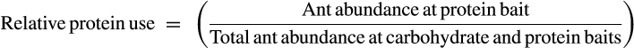

Thus, a value of 0.5 indicates an equal proportion of ants on carbohydrate and protein baits while values greater than 0.5 indicate a greater use of protein compared with carbohydrate. So that we had one value of protein use per height, we calculated the mean between pairs of baits at each sampling station. Relative carbohydrate use was also calculated using a similar formula; for methods and analyses of relative carbohydrate use, see Appendix S4. We also calculated relative protein use separately for each species by pooling abundance across baits and trees to give a single abundance value for protein and carbohydrate baits for each species. We used linear mixed models in the “lme4” package (Bates, Machler, Bolker, & Walker, 2015) to examine how much variation in protein use could be explained by height aboveground. The response variable, relative protein use, was logit transformed to meet Gaussian assumptions as recommended for proportional data (Warton & Hui, 2011). In addition to height aboveground, we also included tree species as an explanatory factor for protein use. To test the significance of predictors in the model, we calculated *p*‐values based on Satterthwaite's approximation using the “lmerTest” package (Kuznetsova, Brockhoff, & Christensen, 2017). To plot model predictions, logit values were rescaled back to an index of 0–1 for relative protein or carbohydrate use.

To assess whether height aboveground, bait type (carbohydrate/protein) or the interaction between these factors influenced species richness or ant abundance (log<sub>10</sub> transformed), we used similar linear mixed models. For all models, we included a random factor of tree nested within plot to account for pseudo‐replication and visual inspection of residual plots did not reveal any obvious deviations from homoscedasticity or normality. An information‐theoretic approach using bias‐corrected Akaike information criterion (AICc) was used to arrive at the best descriptive model (Burnham & Anderson, 2002; Hurvich & Tsai, 1989). To evaluate the variance of the data explained by each model, we calculated marginal (fixed effects) and conditional (fixed and random effects) *R*<sup>2</sup>, using the methods of Nakagawa and Schielzeth (2013) and the function “r.squaredGLMM” in the package “MuMIn” (Barton, 2018). For bait use, species richness and abundance, we analyzed the data by all species pooled and by common and rare ants. Common ants were defined as those that made up 90% of the total ant abundance, while rare ants were defined as those that made up the remaining 10% of the total abundance.

Differences in species composition with bait type (carbohydrate/protein) were assessed using non‐metric multidimensional scaling (NMDS) and the non‐parametric permutational multivariate analysis of variance (PERMANOVA) using the “metaMDS” and “adonis” function within the “vegan” package (Oksanen et al., 2019). Bray–Curtis dissimilarity matrices were used in both the NMDS and PERMANOVA analyses, as recommended for multivariate ecological datasets (Beals, 1984). Species abundance was first pooled across all traps with the same bait (carbohydrate or protein) within the same tree. Relative abundance was square root transformed to reduce the effect of abundant species, due to the large number of rare species, and used to calculate Bray–Curtis dissimilarity matrices. The NMDS analysis was restricted to two dimensions with the number of iterations curtailed at 999 and the number of random starts at 250. We ran the PERMANOVA analysis with 999 permutations and checked for homogeneity of group dispersions using the function “permutest.betadisper” in the “vegan” package (Oksanen et al., 2019). When species composition differed, we performed an analysis of similarity percentages (SIMPER; Clarke, 1993) to determine which species contributed most to the Bray–Curtis dissimilarities.

We also checked for compositional differences according to tree species by visualizing using NMDS and assessing for significant differences in species composition among tree species using a PERMANOVA test. For this last analysis, species abundance was pooled across all traps, regardless of bait, within the same tree; otherwise, the same settings were used as for the above multivariate analysis (see Appendix S2 and Figure S2.3).

Null model analyses of species co‐occurrence were carried out using the function “cooc_null_model” in the package “EcoSim” (Gotelli, Hart, & Ellison, 2015). We used the C‐score (Stone & Roberts, 1990) as our metric for examining patterns in species co‐occurrence (see Fayle, Turner, & Foster, 2013; Janda & Konečná, 2011; Pfeiffer, Cheng Tuck, & Chong Lay, 2008). A presence–absence matrix was constructed with all recorded ant species as rows and individual trees as columns (124 rows x 12 columns). We compared observed C‐scores with C‐scores generated from 10,000 randomly constructed null assemblages using the fixed‐equiprobable algorithm (“Sim 2,” Gotelli, 2000); an upper and lower *p*‐value was generated from each simulation, with a significance threshold of .025. An observed C‐score significantly greater than that expected by chance indicates that species are non‐randomly distributed and are instead segregated, as predicted by the presence of an ant mosaic. Conversely, an observed C‐score significantly lower than that expected by chance indicates that species are aggregated. We repeated this analysis using species found either in the canopy or trunk, and again using only the common species. As ant mosaics predict negative species interactions between dominant species, restricting analysis to only the dominant species when species richness is very high can allow for more meaningful comparisons to be made (Blüthgen & Stork, 2007). When negative co‐occurrence was detected, we performed pairwise analyses to assess the co‐occurrence for each pair of species separately to determine which species pairs were responsible for the negative associations.

## 3 RESULTS

### 3.1 Protein use, species richness and species composition

In total, 26,608 ants were collected belonging to 124 morphospecies, 26 genera, and five subfamilies; of these, 22,430 were found on protein baits. The best descriptive model for protein use was also the simplest: Height aboveground was the best predictor of protein use (see Table 1 and Table S4.2). Relative protein use increased with increasing height aboveground (*t* = 5.367, *df* = 82.2, *p* < .001) (Figure 1a). Conversely and correspondingly, relative carbohydrate use decreased with height (see Appendix S4). The best descriptive model for variation in species richness included both height aboveground and bait type (see Table 1 and Table S4.6). Species richness was higher in traps with carbohydrate baits compared with protein baits (*t* = 5.513, *df* = 170.0, *p* < .001), and species richness increased with height aboveground on both bait types (*t* = 3.990, *df* = 173.4, *p* < .001) (Figure 2a).

Table 1. Comparative and summary statistics for mixed‐effects models explaining variation in protein use and species richness for all ants

[output not shown]

### Note

- The response variable of protein use was logit transformed to meet Gaussian assumptions, and explanatory variables included fixed effects of height and tree species.
- We assumed a Poisson distribution for the response variable of species richness and explanatory variables included height and bait type.
- All mixed models included a random effect of tree nested within plot. Listed are the degrees of freedom (*df*), log‐likelihood (LL), bias corrected Akaike’s information criterion (AICc), and its change relative to the best descriptive model (ΔAICc).
- Marginal *R*<sup>2</sup> (*R*<sup>2</sup><sub>m</sub>) shows the amount of variation explained by the fixed effects in the logit transformed model while conditional *R*<sup>2</sup> (*R*<sup>2</sup><sub>c</sub>) shows that explained by fixed and random effects.
- The most parsimonious models (for protein preference and species richness) are highlighted in bold.

Species composition differed significantly between carbohydrate and protein baits (PERMANOVA, *R*<sup>2</sup> = .089, *F*<sub>1,22</sub> = 2.151, *p* = .017) (Figure 4). SIMPER analysis revealed that six species accounted for 40% of dissimilarity between carbohydrate and protein baits, and all of these were common species (Table S2.1). Tree species did not affect ant species composition (PERMANOVA, *R*<sup>2</sup> = .616, *F*<sub>7,4</sub> = 0.915, *p* = .605) (Figure S2.3).

### 3.2 Common and rare species

Eight species comprised 90% of the total abundance, belonging to six genera (*Monomorium, Vollenhovia, Crematogaster, Dolichoderus, Camponotus,* and *Polyrhachis*), while 116 species made up the remaining 10% from 25 genera (Figure S2.1a). While total ant abundance increased with increasing height aboveground, this was driven by the common species and not rare species, and the increase in abundance was less steep in carbohydrate than protein baits (see Appendix S3 for statistical results). The best descriptive model used to examine patterns in protein use for all species was also used to examine patterns for common and rare species (Table S4.1). Although protein use increased with increasing height aboveground for common species (*t* = 4.113, *df* = 84.6, *p* < .001), protein use (or carbohydrate use) did not change with height for rare species (*t* = −0.709, *df* = 90.2, *p* = .480) (Tables S4.2 & S4.4; Figure 1b & c, Figure S4.1). The best descriptive model for species richness included height and bait type for all species and common species but only bait type for rare species (Tables S4.5 & S4.6). Species richness increased with height for common species (*t* = 7.322, *df* = 176.7, *p* < .001) but not for rare species (Figure 2b,c). Although species richness was higher on carbohydrate baits compared with protein baits for both common (*t* = 2.585 *df* = 172.3, *p* = .011) and rare species (t = 5.239, *df* = 171.9, *p* < .001), generally, species richness remained lower for common species than rare species with more rare species co‐occurring on the same baits (Figure 2b,c). Relative protein use for common species was significantly higher than 0.5 (i.e. no preference and equal use of bait types) (mean protein use *SE* = 0.80 0.12; non‐parametric Wilcoxon test: *V* = 33, *p* = .039); however, the relative protein use for rare species was significantly lower than 0.5 (mean protein use *SE* = 0.29 0.42; Wilcoxon: *V* = 49, *p* < .001), indicating a greater use of carbohydrate than protein for rare species (Figure 3).

### 3.3 Species co‐occurrence

Ant species co‐occurrence was random at the whole tree level and trunk level with observed C‐scores close to the mean C‐score of simulated matrices for the fixed‐equiprobable model (Figure 5a,c, Table S5.1), but species co‐occurrence was aggregated at the canopy level (*C*<sub>obs</sub> = 1.893, *C*<sub>null</sub> = 2.021, *p*<sub>obs<null</sub> = 0.008) (Figure 5b). However, for common species observed C‐scores were significantly greater than the mean C‐score of simulated matrices indicating a non‐random and segregated distribution at the canopy level (*C*<sub>obs</sub> = 6.833, *C*<sub>null</sub> = 3.896, *p*<sub>obs>null</sub> = 0.002), but not at the whole tree and trunk level (Figure 5d‐f & Table S5.1). Of the four common species found in the canopy, two species pairs were responsible for the segregated distribution (*Monomorium.7* & *Vollenhovia.3 p*<sub>obs>null</sub> = 0.018, and *Monomorium.7* & *Crematogaster.5 p*<sub>obs>null</sub> = 0.043) (Table S5.3). Both species pairs showed a segregated distribution in the canopy despite being abundant in the same plot.

## 4 DISCUSSION

Resource limitation underlies competition and species co‐existence and is therefore fundamental to understanding community structure. Given that nitrogen is a limiting resource in the canopy (Davidson, 1997), when given a choice, ants should prefer the bait type containing the limiting nutrient (Yanoviak & Kaspari, 2000). Our results agree with this premise as we found that ants foraging at greater heights showed a stronger use of protein baits, indicative of protein preference (Figure 1). Indeed, our results demonstrating greater protein use are in concordance with other studies on bait‐choice (Hashimoto et al., 2010; Kaspari & Yanoviak, 2001; Yanoviak & Kaspari, 2000). We also show that species richness increases with foraging height regardless of the type of bait used (Figure 2). The observed increase in species richness with height is consistent with previous studies for ants (Janda & Konečná, 2011) and other arthropods (Basset et al., 2001) and may be explained by more feeding and nesting opportunities in the canopy compared with the trunk and understory (Bassett et al., 2001; Janda & Konečná, 2011). However, unlike other studies, we examined patterns separately according to the numerical dominance of species. We found that patterns in protein use and species richness were driven by a few common (numerically dominant) ant species but not rare ant species (Figures 1 & 2).

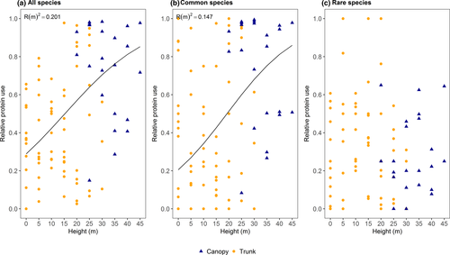

**Figure 1**

Relative protein use shown by (a) all ants, (b) common ants, and (c) rare ants at traps baited with carbohydrate or with protein and set at different heights above the ground across 12 trees (*n* = 12). When height is a significant predictor of relative protein use, *R*<sup>2</sup>m (fixed effects) from the logit transformed model are shown and lines display model predictions (relative protein use is rescaled back from the logit transformation). Traps set in the canopy are shown as blue triangles and on the trunk as yellow circles. Common ants comprise 90% of total ant abundance and rare ants the remaining 10%

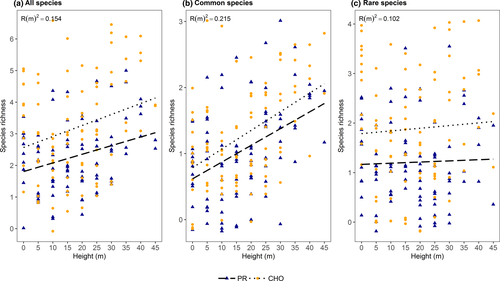

**Figure 2**

Species richness at carbohydrate (CHO) and protein (PR) baits for (a) all ants, (b) common ants, and (c) rare ants at different heights above the ground across 12 trees (*n* = 12). Lines display model predictions and *R*<sup>2</sup>m (fixed effects) are shown. Protein baits are shown as blue triangles and carbohydrate baits as yellow circles. Common ants comprise 90% of total ant abundance and rare ants the remaining 10%. Lines display model predictions using bait type and height as predictors, *R*<sup>2</sup>m (fixed effects) are shown. Jitter has been added in the y‐plane so that individual data points are clearly identifiable

The ability of some ant species to exploit the carbohydrate‐rich resources in the canopy has been suggested as the reason for their high abundances (Davidson, 1997; Davidson & Patrell‐Kim, 1996; Tobin, 1991) and has been demonstrated through field and laboratory studies. In the canopy, dominant ants (in both numerical and behavioral dominance) will monopolize predictable carbohydrate resources such as honeydew, while non‐dominant species rely on more opportunistic resources (Blüthgen et al., 2004, 2000). And although stable isotope studies have revealed that some arboreal ants have a largely herbivorous diet, a high degree of omnivory is also evident (Blüthgen et al., 2003; Davidson et al., 2003). As such our finding that there is large variation in protein use among arboreal species is not surprising, we might expect numerically dominant species to show greater protein use due to their largely specialized herbivorous diet. For example, the greater protein use we detected in common *Crematogaster* and *Dolichoderus* species may be expected as species within these genera are reported to substantially depend on plant resources and can exhibit digestive organs modified for feeding on large volumes of liquid (Davidson, 1997).

While most common ant species showed greater protein use, this was not true for rare species (Figure 3). Furthermore, we found differences in species composition between carbohydrate and protein baits (Figure 4) and greater species richness of rare species on carbohydrate baits compared with protein baits (Figure 2c). These findings imply that rare species were more likely to be found on carbohydrate than protein baits. We suggest two explanations for these findings: (a) That common ant species were monopolizing protein baits and preventing occupation by rare species, or (b) that rare species did not show greater protein use as they are not as limited by nitrogen in their diet.

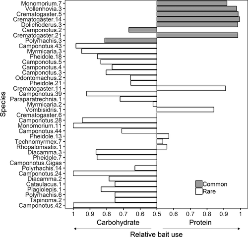

**Figure 3**

Relative bait use for ant species that make up 99% of total ant abundance (39 from 124 species identified); each species has a total abundance of 10 or more. Relative bait use is calculated as the proportion of ants found on carbohydrate or protein baits (from 0 to 1.0). For example, 0.5 indicates equal use of carbohydrate and protein baits. Ants classified as common (*n* = 8) and rare (*n* = 31) are indicated as grey or white bars, respectively. Species names consist of the genus followed the morphospecies ID number in brackets. Common species comprise 90% of total ant abundance, and rare species comprise the remaining 10%

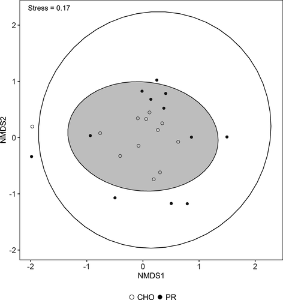

**Figure 4**

Nonmetric multidimensional scaling (NMDS) ordinations (Bray–Curtis measure) comparing species composition on carbohydrate and protein baits on each tree (*n* = 12 trees). Ellipses indicate 95% confidence intervals of the group centroids. The stress value shows the agreement between the 2D configuration shown here and the predicted values from the regression, and values less than 0.2 indicate a good representation

While the term dominant can refer to both numerical and behavioral dominance (Parr & Gibb, 2010), measures of abundance and behavior are not always possible. Yet as high abundance (numerical dominance) often correlates with behavioral dominance (Davidson, 1998; Morrison, 1996; Savolainen, Vepsäläinen, & Vepsalainen, 1988), we may expect common species in this study (numerically dominant) to exclude rare species from protein baits. Indeed, baiting studies have demonstrated that dominant species will aggressively defend a resource leading to competitive exclusion (Andersen, 1992; Parr, 2008) and, in tropical forests, this occurs more frequently in the upper canopy compared with the lower canopy (Ribeiro, Espírito Santo, Delabie, & Majer, 2013) and the ground (Yanoviak & Kaspari, 2000). Unlike aggressive dominant species, competitively less aggressive non‐dominant species will co‐exist on the same resource (Blüthgen et al., 2004), and this may explain the greater species richness of rare ants we found on carbohydrate baits. Competitive exclusion at baits may also explain why two common species belonging to the genera *Camponotus* and *Polyrhachis* did not show a greater use of protein baits despite species within these genera specializing on feeding from exudates or extrafloral nectaries (Blüthgen et al., 2004; Davidson & Patrell‐Kim, 1996); both genera are typically subordinate in the behavioral dominance hierarchy (Andersen, 1995; Hölldobler, 1983), thus it is possible they were also excluded from protein baits.

Alternatively, it may be that rare species truly do not use protein baits more as they are not as nitrogen‐limited as common species. Rare species show no change in either protein or carbohydrate use with height (Figure 1 & Figure S4.1) despite the increase in abundance of common species at greater heights (Figure S3.1) where exclusion may occur more frequently. Although dominant species have been found to monopolize specific resources, such as honeydew, at other resources co‐occurrence between dominant and non‐dominant species can occur (Blüthgen et al., 2004). Furthermore, the lack of co‐occurrence between dominant species in the canopy (Blüthgen et al., 2004; Pfeiffer et al., 2008) suggests that interspecific competition may be greater between dominant species than between dominant and non‐dominants. And, while we found no evidence of negative species interactions between all species among trees (Figure 5a‐c), when species co‐occurrence analyses consider the distribution of only the common species we do find more negative interactions among the canopies of sampled trees (Figure 5e). This suggests that interspecific competition is important in structuring the distribution of common species, and however, this negative co‐occurrence was driven by only a few species pairs (Appendix S5). Although two species pairs were common within the same plot, they were segregated among the canopies of sampled trees within the plot. And, while a lack of species co‐occurrence can be explained by inter‐specific competition it is not possible to infer that competition is the sole cause of exclusive species distributions; other explanations are also possible such as independently evolved habitat preferences, predation pressures, and parasitism (Connor & Simberloff, 1983).

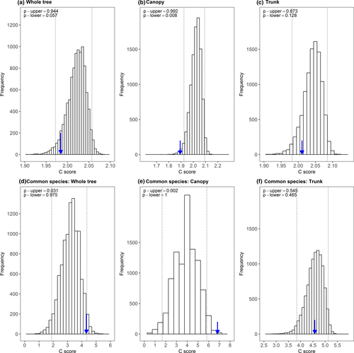

**Figure 5**

The distributions of C‐scores expected using null models at the level of the whole tree, the canopy, and the trunk for all ant species (a–c) and for only common species (d–f). Common species are species that comprise 90% of the total abundance (whole tree, *n* = 8 species; canopy, *n* = 4 species; trunk, *n* = 16 species). Arrows denote observed C‐scores for each ant assemblage, and the broken lines indicate upper and lower 95% confidence interval (two‐tailed). Upper and lower *p*‐values are shown with α = 0.025). A high C‐score to the right of the broken line indicates that there are fewer co‐occurrences between species than would be expected by chance and thus a high degree of segregation between species. A lower C‐score to the left of the broken line indicates that there are more co‐occurrences between species than would be expected by change and a high degree of aggregation between species

Co‐existence of common (numerically dominant) and rare ants at baits may be promoted by differences in foraging strategies. The presence of trade‐offs, such as negative correlations between dominance and resource discovery (Adler, LeBrun, & Feener, 2007; Fellers, 1987) or dominance and thermal tolerance (Cerdá, Retana, & Manzaneda, 1998; Lessard, Dunn, & Sanders, 2009), can prevent dominant species monopolizing resources and thus allow non‐dominants access their bait of choice. Furthermore, competitive exclusion can be avoided through temporal niche differentiation with dominant and non‐dominant species foraging at difference times of the day (Houadria, Salas‐Lopez, Blüthgen, Orivel, & Menzel, 2015). In this study, baited traps were left open for 24 hr and thus rare species may not have been excluded from baits due to temporal differences in foraging strategy.

Further studies are needed to determine whether rare species lack a protein preference and are therefore not limited by nitrogen in the same way as common species, specifically, (a) observations of competitive interactions between common and rare species in the canopy, and (b) bait‐choice experiments for rare species with the exclusion of common species.

There are a number of caveats to our findings. The large distance between some of our surveyed trees (≥100 m) prevents the identification of ant mosaics per se as there was no continuous canopy to detect territory boundaries. Rather, co‐occurrence analysis identified that different species were numerically dominant in different trees. The use of baits also has a number of shortcomings: (a) Baits do not represent natural resources and are generally richer than those normally foraged for by ants, thus ants may forage and defend more intensively these rich resources (Ribas & Schoereder, 2002); (b) as highlighted in a bait‐choice experiment by Kaspari and Yanoviak (2001), although we designated honey and oats as a carbohydrate resource and tuna as protein, each bait type will differ with regard to other nutrients and it may be that ants are showing a preference for fats or salt in the tuna rather than protein; (c) the use of baited traps is innately selective and will not sample the entire ant community unless used in conjunction with other techniques, such as beating or hand collection. However, despite these limitations, baiting is recognized as a useful technique in studying the structure of ant communities (Blüthgen & Stork, 2007; Dejean et al., 2007).

To summarize, we add to the growing evidence of nitrogen limitation in the canopy. However, our results indicate that this should not be generalized for a whole assemblage of ants. The increase in protein use with height (and inferred nitrogen limitation) shown by ants can be attributed to common species. This increase in protein use (indicative of protein preference) is likely due to their ability to exploit carbohydrate‐rich resources resulting in a diet limited in nitrogen, and however, these species comprise only a small proportion of the total ant assemblage (only 6% of all species in our study made up 90% of total ant abundance). If differences in temporal foraging among ant species allow rare species access to protein baits, then our results suggest that most arboreal ant species do not show a greater use of protein and are not limited by nitrogen. However, we are unable to rule out that a lack of rare species at protein baits is due to competitive exclusion by common ants.

Furthermore, we find evidence for a segregated species distribution among common species in the canopy, indicating the possible presence of ant mosaics. While ant mosaics have been detected often in tropical agricultural plantations, their presence in primary forest has been debated (Blüthgen & Stork, 2007; Fayle et al., 2013; Floren & Linsenmair, 2000; Majer, 1972), yet recently ant mosaics have been found in pristine rain forest, particularly in the upper canopy (Dejean et al., 2019). Further studies deciphering differences in bait‐choice between dominant (including both numerical and behavioral dominance) and non‐dominant species are required to improve our understanding of how resources structure ant communities along a vertical gradient in tropical rain forest.

## ACKNOWLEDGMENTS

This publication is a contribution from the UK NERC‐funded Biodiversity and Land‐use Impacts on Tropical Ecosystem Function (BALI) consortium (http://bali.hmtf.info) (NERC grant no. NE/L000016/1) and was supported by the South‐East Asian Rainforest Research Partnership (SEARRP) with permission from the Maliau Basin Management Committee. SL was funded by the University of Liverpool. We thank all our hardworking field assistants and Charles Vairappan of Universiti Malaysia Sabah for support throughout. We thank Glen Reynolds, Unding Jami and Laura Kruitbos for coordinating fieldwork, and Sabine Both and Ully Kritzer for help in establishing the experimental plots. Particular thanks go to FreDino John and Almuis Jupri for assistance with tree climbing. We are grateful to the anonymous reviewers who provided helpful comments that greatly improved this manuscript.

## AUTHOR CONTRIBUTIONS

SL designed the study, performed research, analyzed data, and wrote the paper. CP designed the study and contributed critically to drafts.